# 1-phase rectifier

A single 500$\mu$s duration pulse is used to turn-on switch $SW$ as shown below. Determine the peak voltage appearing across the switch.

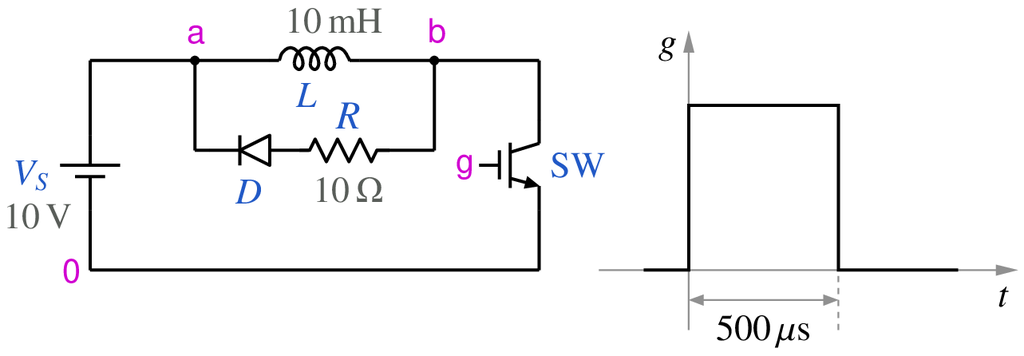

```python
from IPython.display import Image
Image(filename =r'rectifier_1ph_5_fig_1.png', width=600)
```

```python
# run this cell to view the circuit file.
%pycat rectifier_1ph_5_orig.in
```

We now replace the strings such as `\$R` with the values of our choice by running the python script given below. It takes an existing circuit file `rectifier_1ph_5_orig.in` and produces a new circuit file `rectifier_1ph_5.in`, after replacing `\$R` (etc) with values of our choice.

```python
import gseim_calc as calc
import numpy as np

s_R = "10"
s_L = "10e-3"

l = [
  ('$R', s_R),
  ('$L', s_L),
]
calc.replace_strings_1("rectifier_1ph_5_orig.in", "rectifier_1ph_5.in", l)
print('rectifier_1ph_5.in is ready for execution')
```

```
rectifier_1ph_5.in is ready for execution
```

**Execute the following cell to run GSEIM on rectifier_1ph_5.in.**

```python
import os
import dos_unix
# uncomment for windows:
#dos_unix.d2u("rectifier_1ph_5.in")
os.system('run_gseim rectifier_1ph_5.in')
```

```
Circuit: filename = rectifier_1ph_5.in
main: calling solve_startup
SysMat::mat_startup_1_x starting...
main: i_solve = 1
main: calling solve_trns
Transient simulation starts...
i=0
i=1000
i=2000
i=3000
i=4000
i=5000
i=6000
i=7000
i=8000
i=9000
GSEIM: Program completed.
```

```
0
```

The circuit file (`rectifier_1ph_5.in`) is created in the same directory as that used for launching Jupyter notebook. The last step (i.e., running `GSEIM` on `rectifier_1ph_5.in`) creates a data file called `rectifier_1ph_5.dat` in the same directory. We can now use the python code below to compute/plot the various quantities of interest.

```
filename: rectifier_1ph_5.dat
```

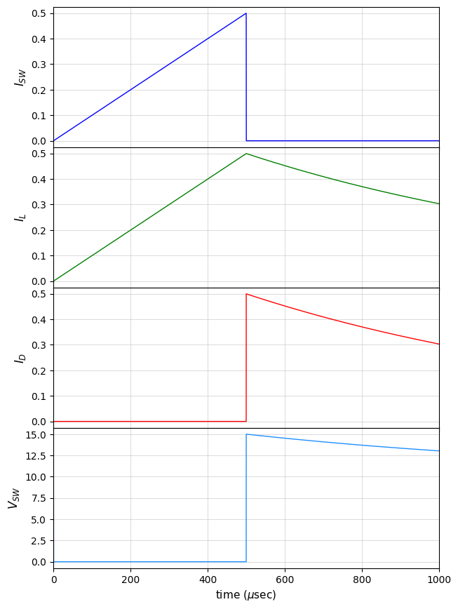

```python
import numpy as np
import matplotlib.pyplot as plt
import gseim_calc as calc
from setsize import set_size

slv = calc.slv("rectifier_1ph_5.in")

i_slv = 1
i_out = 0
filename = slv.l_filename_all[i_slv][i_out]
print('filename:', filename)
u = np.loadtxt(filename)
t = u[:, 0]

ID    = slv.get_array_double(i_slv,i_out,"ID",u)
IL    = slv.get_array_double(i_slv,i_out,"IL",u)
I_SW  = slv.get_array_double(i_slv,i_out,"I_SW",u)
V_SW  = slv.get_array_double(i_slv,i_out,"V_SW",u)

# get value of t_end from the circuit file:
fin = open("rectifier_1ph_5.in", "r")
for line in fin:
    if 't_end' in line:
        s = line.replace("\n","")
        t_end = float(s.split('=')[1])

color1='blue'
color2='green'
color3='red'
color4='dodgerblue'

fig, ax = plt.subplots(4, sharex=False)
plt.subplots_adjust(wspace=0, hspace=0.0)

set_size(5.5, 8, ax[0])

for i in range(4):
    ax[i].set_xlim(left=0.0, right=t_end*1e6)
    ax[i].grid(color='#CCCCCC', linestyle='solid', linewidth=0.5)

ax[0].set_ylabel(r'$I_{SW}$', fontsize=12)
ax[1].set_ylabel(r'$I_L$'   , fontsize=12)
ax[2].set_ylabel(r'$I_D$'   , fontsize=12)
ax[3].set_ylabel(r'$V_{SW}$', fontsize=12)

for i in range(3):
    ax[i].tick_params(labelbottom=False)

ax[0].plot(t*1e6, I_SW, color=color1, linewidth=1.0, label="$I_{SW}$")
ax[1].plot(t*1e6, IL  , color=color2, linewidth=1.0, label="$I_L$")
ax[2].plot(t*1e6, ID  , color=color3, linewidth=1.0, label="$I_D$")
ax[3].plot(t*1e6, V_SW, color=color4, linewidth=1.0, label="$V_{SW}$")

ax[3].set_xlabel(r'time ($\mu$sec)', fontsize=11)

#plt.tight_layout()
plt.show()
```

This notebook was contributed by **Prof. Nakul Narayanan K**, Govt. Engineering College, Thrissur. He may be contacted at nakul@gectcr.ac.in.